# The rptPlus Sample Vignette

Boris Steipe

http://orcid.org/0000-0002-1134-6758  
University of Toronto

boris.steipe@utoronto.ca

2019-04-12

#### Abstract

The rptPlus Sample Vignette demonstrates markdown syntax for the creation of a Bioconductor-compatible Vignette, and serves as a template that can be customized for your own contents.

There are many links and references in this document. If you find anything here ambiguous, inaccurate, outdated, incomplete, or broken, please [file an issue](https://github.com/hyginn/rpt/issues)!

# 1 About this Vignette

This sample Vignette explains how to customize this template for your own R package, and it contains hints on how to create meaningful contents. Thus the Vignette is a template for your own development - both in how it integrates with the rest of the package framework, and what you can do with it. Edit it to your needs. But do make sure your package **has** a Vignette! Obviously, the code and data assets contain comment headers throughout, and these are used by roxygen2 to compile package documentation and man pages. However, **documenting what the functions do does not necessarily explain how to use a package**.

The `.Rmd` format in which this Vignette is written is a very clever way to enable [“literate programming”](https://en.wikipedia.org/wiki/Literate_programming): the source combines [markdown](https://www.rstudio.com/wp-content/uploads/2015/02/rmarkdown-cheatsheet.pdf) formatted text with executable R code, and the results of the code are integrated into the resulting document. This magic is made possible by the fabulous [knitr package](https://en.wikipedia.org/wiki/Knitr), originally written by [Yihui Xie](https://yihui.name/en/about/) and integrated into the RStudio IDE.

`knitr` can render the Rmarkdown contents of this Vignette to a variety of different formats, including html and pdf. Which format is targeted is defined in the metadata block at the top of the Vignette. Specifically, the format used here is [“`BiocStyle::html_document`”](https://bioconductor.org/packages/release/bioc/vignettes/BiocStyle/inst/doc/AuthoringRmdVignettes.html), which is a requirement for Bioconductor packages. An alternative format that is often used in CRAN and other packages is [“`html_vignette`”](https://bookdown.org/yihui/rmarkdown/r-package-vignette.html); this format aims to produce a vignette that is as small as possible.

# 2 Develop your Vignette

In RStudio, open the `./vignettes` folder and rename `rptPlus.Rmd` to `<your-package-name>.Rmd. Then open the file to edit it. Whenever you make changes, click on the **Knit** icon at the top of the editing pane, this will save the file, “knit” the output to an html file, and open the file in the viewer. You can also copy the path of the resulting file from the **R Markdown** tab in the console pane and open it in your normal browser.

## 2.1 Customize the metadata

Edit the following information in the metadata block:

### 2.1.1 Your Vignette Title

In the header block, change your Vignette title and the Vignette index entry:

```
-   title: "The rptPlus Sample Vignette"
+   title: "<your-Vignette-title>"
```

```
vignette: >
  %\VignetteIndexEntry{The rptPlus Sample Vignette}
  %\VignetteIndexEntry{<your-Vignette-title>}
[...]
```

### 2.1.2 Author and Affiliation

The author name and affiliation in the document header are also generated from metadata. You can list several authors with their shared and unique affiliations and provide a linked email address to the corresponding author. For details, see [here](https://bioconductor.org/packages/release/bioc/vignettes/BiocStyle/inst/doc/AuthoringRmdVignettes.html#31_author_affiliations).

```
author:
-   - name: Boris Steipe
+   - name: <your-name>
     affiliation:
-     - http://orcid.org/0000-0002-1134-6758
+     - http://orcid.org/<your-ORCID-ID>
-     - name: University of Toronto
+     - name: <your-affiliation>
-     email: boris.steipe@utoronto.ca
+     email: <corresponding-author's-email>
```

### 2.1.3 Abstract and Running Headers

An abstract will be processed from the metadata block.

```
abstract: >
-    The rptPlus Sample Vignette demonstrates[...]
+    <your-Vignette-summary>
```

## 2.2 Contents

### 2.2.1 Text

Text in this Vignette is written in R Markdown format. This is reasonably lightweight and intuitive, for details refer to the many documents linked in Section 4 (Further reading) and study the examples in this document.

> A good Vignette is all about workflow. It addresses the divine and elusive **why** of documentation. To paraphrase Henri Poincaré: *a useful package is made from functions as a house is with stones. But a collection of functions is no more useful in itself than a heap of stones makes a house.* Connecting workflow upstream and downstream is the essence of good software, it is the task of the Vignette to make your implicit ideas explicit.

> *“Science is built up with facts, as a house is with stones. But a collection of facts is no more a science than a heap of stones is a house.”* [Henri Poincaré](https://en.wikiquote.org/wiki/Henri_Poincar%C3%A9).

### 2.2.2 Links

Easily accessible cross-references are the lifeblood of academic publishing. Use references liberally to make access to material for in-depth exploration easy.

- **cross references within** the document can be made to figures, tables, equations and section headers (see [here](https://bioconductor.org/packages/release/bioc/vignettes/BiocStyle/inst/doc/AuthoringRmdVignettes.html#9_cross-references)). But since a markdown document is also an HTML document, you can flexibly create “anchors” anywhere in the document with `<a name="<some-id>"><some-text></a>` and link to them either with markdown syntax: `[<linked-text>](#<some-id>)` or with HTML syntax: `<a href="#<some-id>"><linked-text></a>`. For example this link as well as this link both lead to an anchor at the top of the “Further reading” section (however with differing behaviour regarding where the top of the browser window is positioned).
- **external links** can also be made in markdown and HTML, the markdown syntax is `[<linked-text>](<URL>)`. For example [this link](https://gist.github.com/hyginn/c15e697223c45b5e16b3e90300807e45) leads to my “Gist” for link-checking code in R.
- `BiocStyle` provides macros for **linking to other R packages** in BioConductor, CRAN, on GitHub and elsewhere:

Table 1: BiocStyle link macros

| For … | type … | to get: |
| --- | --- | --- |
| Bioconductor: | `` `r Biocpkg("BiocStyle")` `` | *BiocStyle* |
| CRAN: | `` `r CRANpkg("knitr")` `` | *knitr* |
| GitHub: | `` `r Githubpkg("hyginn/rptPlus")` `` | *rptPlus* |

The above example also shows how to caption a table and place an anchor for a link (for the link itself, see below).

### 2.2.3 Math

R markdown supports the rendering of equations with LaTeX markup. Here is an example:

The golden ratio $\phi$ is

$$\frac{\left(1 + \sqrt{5}\right)}{2}$$

A “golden spiral” is a logarithmic spiral whose radius diminishes by $\frac{1}{\phi}$ every quarter turn. It is thus inscribed into a “golden rectangle”. The golden spiral with initial radius 1 is defined by the polar equation

cf. [“Golden spiral” on Wikipedia](https://en.wikipedia.org/wiki/Golden_spiral).

$$\begin{equation}
r = \phi^{-\theta\frac{2}{\pi}}
\tag{1}
\end{equation}$$

### 2.2.4 Figures

The block of R code below is executed when the document is knit, and the resulting plot is shown. The code first sets up `N` angles `theta` and then computes the radius according to (1) . Polar coordinates are then converted to cartesian coordinates and scaled to the canonical golden rectangle. We plot an empty frame, draw the rectangle, draw segments for the enclosed golden sections, and finally draw the line of the spiral.

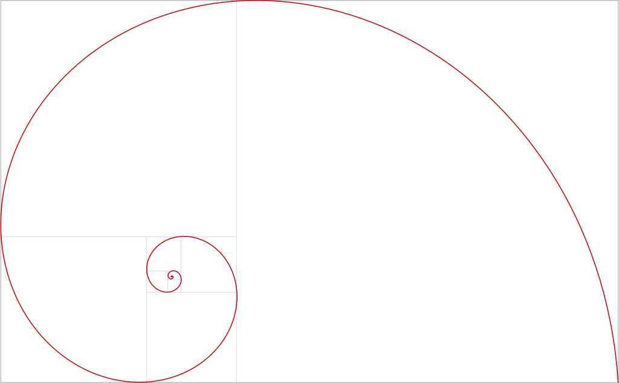

Figure 1: The golden spiral is shown in its enclosing golden rectangle

```r
phi <- ((1 + sqrt(5)) / 2)^(1:-8)           # ten decreasing powers of phi
tStart <- -0.233
tEnd <- 8 * pi
N <- 800
theta <- seq(tStart, tEnd, length.out = N)
r = phi[1]^-(theta * (2  / pi))
x <- r * cos(theta)
y <- r * sin(theta)

x <- ((x + abs(min(x))) * phi[1]) / (max(x) - min(x))  # scale to [0, phi]
y <-  (y + abs(min(y)))           / (max(y) - min(y))  # scale to [0, 1]

oPar <- par(mar = rep(0.25, 4))             # set thin margins
plot(x, y,                                  # plot empty frame ...
     type = "n",
     xlim = c(0, phi[1]),
     ylim = c(0, 1),
     xlab = "", ylab = "",
     axes = FALSE,
     asp = 1)                               # with fixed aspect ratio

rect(0, 0, phi[1], 1, border = "#CCCCCC")   # draw enclosing rectangle


C <- "#C9C9EE"                              # draw enclosed golden sections
segments(phi[1]-phi[2],            0,phi[1]-phi[2],       phi[2],col=C,lwd=0.4)
segments(            0,phi[2]-phi[3],phi[1]-phi[2],phi[2]-phi[3],col=C,lwd=0.4)
segments(phi[2]-phi[3],            0,phi[2]-phi[3],phi[2]-phi[3],col=C,lwd=0.4)
segments(phi[2]-phi[3],phi[3]-phi[4],phi[1]-phi[2],phi[3]-phi[4],col=C,lwd=0.4)
segments(phi[4]+phi[7],phi[3]-phi[4],phi[4]+phi[7],phi[2]-phi[3],col=C,lwd=0.4)
segments(phi[2]-phi[3],phi[5]+phi[8],phi[4]+phi[7],phi[5]+phi[8],col=C,lwd=0.4)
segments(phi[4]+phi[8],phi[3]-phi[4],phi[4]+phi[8],phi[5]+phi[8],col=C,lwd=0.4)
segments(phi[4]+phi[8],phi[5]+phi[9],phi[4]+phi[7],phi[5]+phi[9],col=C,lwd=0.4)

lines(x, y, col = "#CC0000")               # draw spiral

par <- oPar                                # reset graphics state
```